# 536 Exam 2

Michael Pena

2024-05-04

## Executive Summary

It was asked to find the risks of anastomatic leaking following a colectomy associated with BMI. This is mainly due to patients having the ability to control their BMI before surgery, thus it is important to research this metrics relationship to such a risk. In regards to the first ask, it was found that holding all other metrics constant, for ever unit of BMI increase, there is a 2.7- 15.7% increase in chances for having an anastomatic Leak. By implementing variable selection techniques, we found that the metrics that also mattered aside from BMI were gender, age, tobacco use, diabetes, cancer history, albumin levels, and operation length.

In regards to the two case studies, I have rendered of graphs showing the top 97.5% and lower 2.5% probabilities of a risk over BMI levels from 20 - 50. We find that the first case has a risk of anastomatic leak of 10% at most where as the second case has a higher range of percentage risk ranging to almost 100%.

## Methods

It is important to note that our method of residual diagnostics indicate and overestimation. (on or around -2.5)

## Exploratory Analysis

[figure not shown]

[figure not shown]

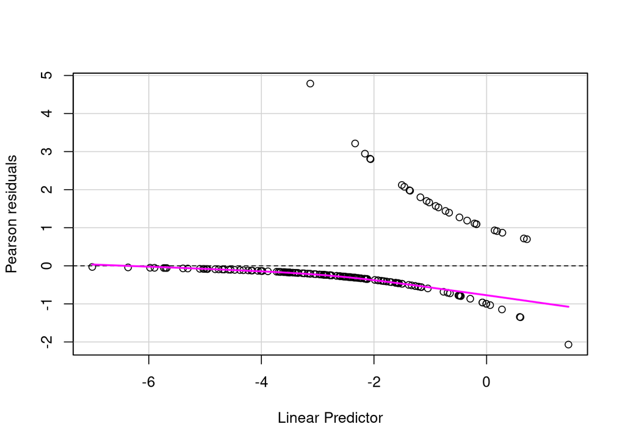

```r
# let's see how well the models predicts
residualPlot(final.model)
```

This is showing us that our model is overestimating.